# STAT340 HW03: Testing I

## 3) Just lucky?

The [National Football League (NFL)](https://en.wikipedia.org/wiki/National_Football_League) is the top league in American football. The league consists of two conferences, the American Football Conference (AFC) and the National Football Conference (NFC). Since 1967, the top team from each of these conferences play against one another in the [Superbowl](https://en.wikipedia.org/wiki/Super_Bowl).

1. As of writing this homework, there have been fifty six (56) Superbowls played. The NFC team has won 29 of these 56 games. Using everything you have learned so far this semester, assess whether or not this constitutes a “surprising” amount of games. Please include a clear explanation of your thought process and how you arrived at your conclusion. As is often the case in these homeworks, there is no strictly right or wrong answer, here, so long as your reasoning is sound and your explanation is clearly written.

I feel like the NFC winning 29 out of 56 games is not a “surprising” amount of games, since due to hypothesis testing, the probability that the NFC wins 29 out of 56 games is about a tenth, which is relatively large.

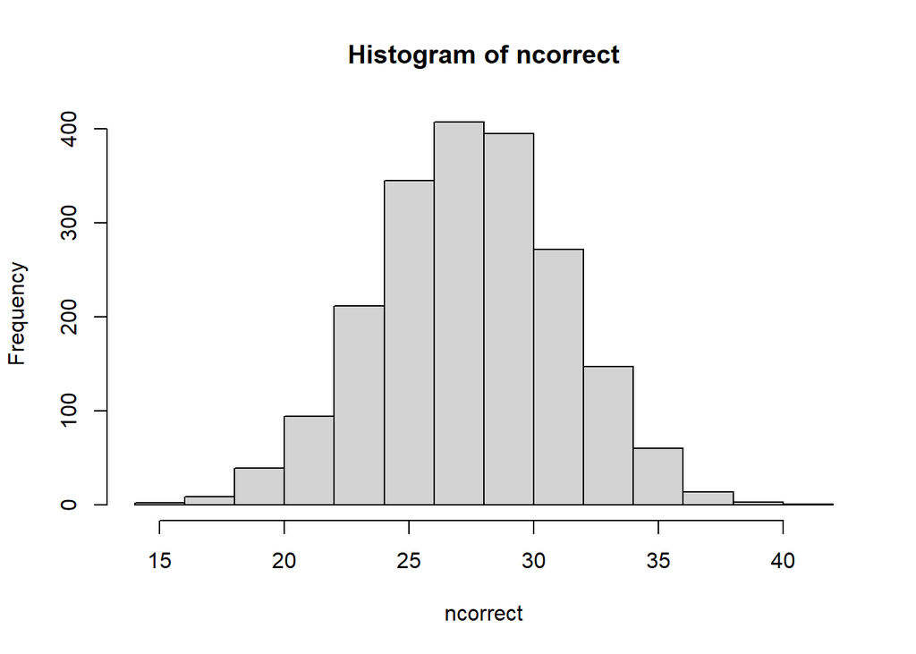

```r
NMC <- 2000;

ncorrect <- rep(0, NMC);
# Monte Carlo
for(i in 1:NMC) {
  # make a random vector of 56 games, with 1s representing wins.
  arr <- rbinom(56, 1, 0.5)
  ncorrect[i] <- sum(arr == 1)
}
# createa histogram
hist( ncorrect )
```

```r
# Find the chance of the NFC winning 29 games.
sum(ncorrect == 29)/NMC
```

```
## [1] 0.1025
```

2. Among those 29 wins by NFC teams, the NFC team won the Superbowl every year from 1985 to 1997 (13 consecutive Superbowls; coincidentally, the last of these was a victory by Wisconsin’s own Green Bay Packers over my hometown team the New England Patriots). Under the assumption that each year’s Superbowl is independent of the others and that the AFC and NFC teams are equally likely to win any given Superbowl, assess how surprising this result is. That is, associate a p-value to the event that the NFC team won all 13 Superbowls in the span 1985 to 1997. Once again, clearly explain your reasoning to get full credit.

Calculating this is simply calculating 0.5 to the power of 13, since there are only two outcomes to a league winning the Super Bowl – the NFC or AFC. Therefore, the solution is 0.0001220703.

```r
# TODO: code goes here.
0.5 ^ 13
```

```
## [1] 0.0001220703
```

3. **Bonus:** (not worth any points; just a fun exercise) Now, let’s zoom out. Write a simulation to estimate how often, under our “independent coinflips” model of the Superbowl, it happens that either of the two conferences (AFC or NFC) wins at least 13 consecutive games. **Hint:** you may find the following function useful, which takes a vector of `0`s and `1`s (e.g., a sequence of Bernoulli RVs) and outputs the length of the longest run.

```r
longestRun = function(x){
    return( max( 0, with(rle(x), lengths) ) )
}

# Example: here's a vector encoding the Superbowl history.
# 0s are AFC, 1s are NFC.
superbowls <- c( 1,1,0,0,0,1,0,0,0,0,0,1,0,0,0,
                 1,1,0,1,1,1,1,1,1,1,1,1,1,1,1,
                 1,0,0,1,0,0,1,0,0,0,0,1,0,1,1,
                 1,0,1,0,0,0,1,0,0,1,1)
longestRun(superbowls)
```

```
## [1] 13
```

```r
# TODO: code goes here,
# if you choose to do this OPTIONAL, NOT WORTH ANY POINTS bonus problem
```